# Predict Popularity

### Full Logistic Model: train/valid/test

fitting logistic model using combo of train/valid/test, finding optimal model using training data.

```r
# Fit logistic model on training data
v.logit.model0 <- glm(popular ~ ., family=binomial(link='logit'),data= logit.train0)

#search for best cutoff
out0 <- opt.cut.func(v.logit.model0, logit.valid0)
```

[output not shown]

[output cut: 164 more lines]

[output not shown]

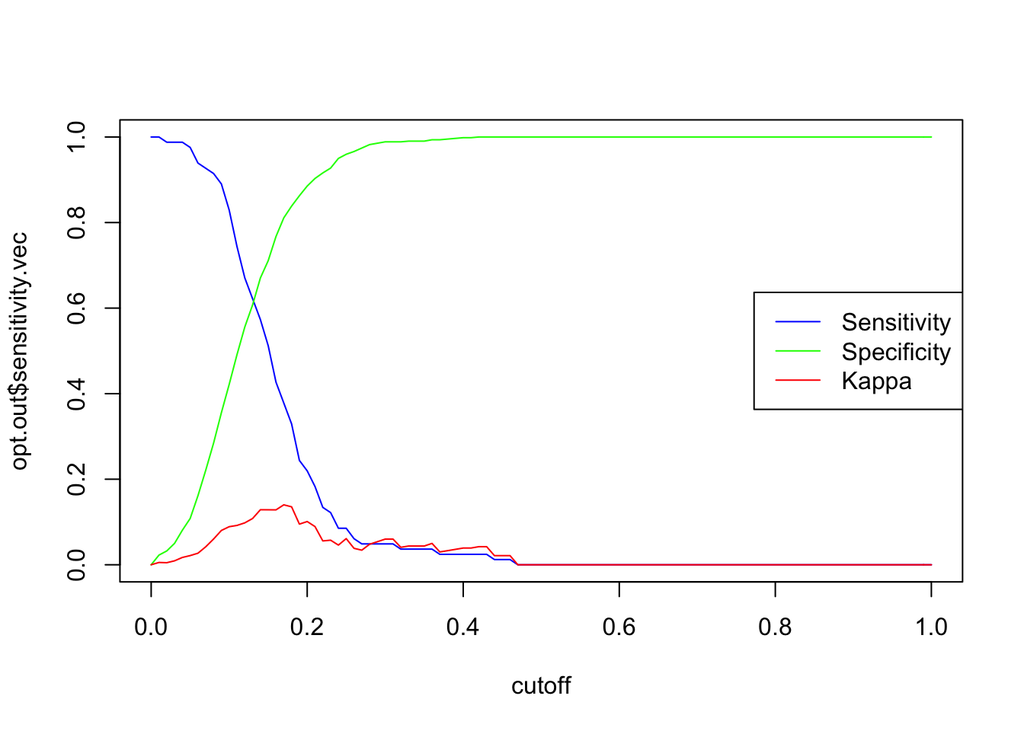

```r
opt.cut.plot(out0)
```

```r
out0$cutoff[which.min(out0$ssdiff.vec)]
```

```
## [1] 0.13
```

```r
v.opt.cut0 <- out0$cutoff[which.max(out0$kappa.vec)]
v.opt.cut0
```

```
## [1] 0.17
```

Fit final model (combo of train and validation)

```r
v.model.final <-  glm(popular ~ ., data=all.train0, family=binomial(link='logit'))
```

predict on test using 0.5 cutoff

```r
v.prob.test <- predict(v.logit.model0, newdata = logit.test0, type = "response")
v.pred.test <- ifelse(v.prob.test > 0.5, 1, 0) # using cutoff = 0.15
confusionMatrix(as.factor(v.pred.test), as.factor(logit.test0$popular), positive = "1")
```

```
## Confusion Matrix and Statistics
##
##           Reference
## Prediction   0   1
##          0 612  86
##          1   2   1
##
##                Accuracy : 0.8745
##                  95% CI : (0.8476, 0.8981)
##     No Information Rate : 0.8759
##     P-Value [Acc > NIR] : 0.5737
##
##                   Kappa : 0.0141
##
##  Mcnemar's Test P-Value : <2e-16
##
##             Sensitivity : 0.011494
##             Specificity : 0.996743
##          Pos Pred Value : 0.333333
##          Neg Pred Value : 0.876791
##              Prevalence : 0.124108
##          Detection Rate : 0.001427
##    Detection Prevalence : 0.004280
##       Balanced Accuracy : 0.504118
##
##        'Positive' Class : 1
##
```

```r
v.prob.test <- predict(v.logit.model0, newdata = logit.test0, type = "response")
v.pred.test <- ifelse(v.prob.test > v.opt.cut0, 1, 0) # using cutoff = 0.16
confusionMatrix(as.factor(v.pred.test), as.factor(logit.test0$popular), positive = "1")
```

```
## Confusion Matrix and Statistics
##
##           Reference
## Prediction   0   1
##          0 492  58
##          1 122  29
##
##                Accuracy : 0.7432
##                  95% CI : (0.7092, 0.7752)
##     No Information Rate : 0.8759
##     P-Value [Acc > NIR] : 1
##
##                   Kappa : 0.1023
##
##  Mcnemar's Test P-Value : 2.656e-06
##
##             Sensitivity : 0.33333
##             Specificity : 0.80130
##          Pos Pred Value : 0.19205
##          Neg Pred Value : 0.89455
##              Prevalence : 0.12411
##          Detection Rate : 0.04137
##    Detection Prevalence : 0.21541
##       Balanced Accuracy : 0.56732
##
##        'Positive' Class : 1
##
```

```r
v.prob.test <- predict(v.logit.model0, newdata = logit.test0, type = "response")
v.pred.test <- ifelse(v.prob.test > 0.13, 1, 0) # using cutoff = 0.13
confusionMatrix(as.factor(v.pred.test), as.factor(logit.test0$popular), positive = "1")
```

```
## Confusion Matrix and Statistics
##
##           Reference
## Prediction   0   1
##          0 373  31
##          1 241  56
##
##                Accuracy : 0.612
##                  95% CI : (0.5748, 0.6482)
##     No Information Rate : 0.8759
##     P-Value [Acc > NIR] : 1
##
##                   Kappa : 0.1234
##
##  Mcnemar's Test P-Value : <2e-16
##
##             Sensitivity : 0.64368
##             Specificity : 0.60749
##          Pos Pred Value : 0.18855
##          Neg Pred Value : 0.92327
##              Prevalence : 0.12411
##          Detection Rate : 0.07989
##    Detection Prevalence : 0.42368
##       Balanced Accuracy : 0.62559
##
##        'Positive' Class : 1
##
```

### Variable Selection: Stepwise (10 fold CV)

step-wise 10 fold cross validation

```r
set.seed(123)
train_control <- trainControl(method = "cv",
                              number = 10)

# Fit K-fold CV model
meh <- capture.output(step0_kcv <- train(popular ~ ., data = logit.train0, family = binomial(),
                 method = "glmStepAIC", trControl = train_control, verbose = FALSE))
```

```r
step0_kcv <- step0_kcv$finalModel
step0_kcv
```

```
##
## Call:  NULL
##
## Coefficients:
##      (Intercept)          duration      acousticness            energy
##           4.8188           -0.5853           -1.2865           -2.9935
## instrumentalness              key3              key4          loudness
##          -6.8551            0.6670           -0.2963            0.3278
##      speechiness           valence
##           3.2727           -1.5873
##
## Degrees of Freedom: 3270 Total (i.e. Null);  3261 Residual
## Null Deviance:       2620
## Residual Deviance: 2458  AIC: 2478
```

```
kcv.prob.test0 <- predict(step0_kcv, newdata = key.dummy(logit.test0), type = "response")
kcv.pred.test0 <- ifelse(kcv.prob.test0 > 0.5, 1, 0) # using cutoff = 0.5
confusionMatrix(as.factor(kcv.pred.test0), as.factor(logit.test0$popular), positive = "1")
```

Find optimal cut off value:

```r
#search for best cutoff
kcv.out0 <- opt.cut.func(step0_kcv, key.dummy(logit.valid0))
```

[output not shown]

[output cut: 172 more lines]

[output not shown]

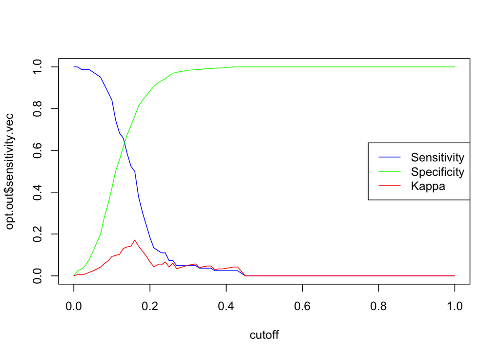

```r
opt.cut.plot(kcv.out0)
```

```r
kcv.out0$cutoff[which.min(kcv.out0$ssdiff.vec)]
```

```
## [1] 0.13
```

```r
kcv.out0.cut0 <- kcv.out0$cutoff[which.max(kcv.out0$kappa.vec)]
kcv.out0.cut0
```

```
## [1] 0.16
```

Fit final model (combo of train and validation)

```r
finalmeh <- capture.output(step0_kcv.final0 <- train(popular ~ ., data = all.train0, family = binomial(),
                 method = "glmStepAIC", trControl = train_control, verbose = FALSE))
step0_kcv.final0 <- step0_kcv.final0$finalModel
step0_kcv.final0
```

```
##
## Call:  NULL
##
## Coefficients:
##      (Intercept)          duration      acousticness            energy
##           5.5013           -0.6027           -1.3582           -3.6454
## instrumentalness              key3              key4          loudness
##          -3.2170            0.5535           -0.3590            0.3566
##      speechiness           valence
##           2.9708           -1.5142
##
## Degrees of Freedom: 3971 Total (i.e. Null);  3962 Residual
## Null Deviance:       3128
## Residual Deviance: 2935  AIC: 2955
```

predict on test using 0.5 cutoff

```r
kcv.prob.test0 <- predict(step0_kcv.final0, newdata = key.dummy(logit.test0), type = "response")
kcv.pred.test0 <- ifelse(kcv.prob.test0 > 0.5, 1, 0) # using cutoff = 0.5
confusionMatrix(as.factor(kcv.pred.test0), as.factor(logit.test0$popular), positive = "1")
```

```
## Confusion Matrix and Statistics
##
##           Reference
## Prediction   0   1
##          0 612  85
##          1   2   2
##
##                Accuracy : 0.8759
##                  95% CI : (0.8492, 0.8994)
##     No Information Rate : 0.8759
##     P-Value [Acc > NIR] : 0.5285
##
##                   Kappa : 0.0334
##
##  Mcnemar's Test P-Value : <2e-16
##
##             Sensitivity : 0.022989
##             Specificity : 0.996743
##          Pos Pred Value : 0.500000
##          Neg Pred Value : 0.878049
##              Prevalence : 0.124108
##          Detection Rate : 0.002853
##    Detection Prevalence : 0.005706
##       Balanced Accuracy : 0.509866
##
##        'Positive' Class : 1
##
```

predict on test using 0.16 cutoff

```r
kcv.prob.test0 <- predict(step0_kcv.final0, newdata = key.dummy(logit.test0), type = "response")
kcv.pred.test0 <- ifelse(kcv.prob.test0 > 0.16, 1, 0) # using cutoff = 0.16
confusionMatrix(as.factor(kcv.pred.test0), as.factor(logit.test0$popular), positive = "1")
```

```
## Confusion Matrix and Statistics
##
##           Reference
## Prediction   0   1
##          0 462  51
##          1 152  36
##
##                Accuracy : 0.7104
##                  95% CI : (0.6753, 0.7438)
##     No Information Rate : 0.8759
##     P-Value [Acc > NIR] : 1
##
##                   Kappa : 0.111
##
##  Mcnemar's Test P-Value : 2.241e-12
##
##             Sensitivity : 0.41379
##             Specificity : 0.75244
##          Pos Pred Value : 0.19149
##          Neg Pred Value : 0.90058
##              Prevalence : 0.12411
##          Detection Rate : 0.05136
##    Detection Prevalence : 0.26819
##       Balanced Accuracy : 0.58312
##
##        'Positive' Class : 1
##
```

predict on test using 0.13 cutoff

```r
kcv.prob.test0 <- predict(step0_kcv.final0, newdata = key.dummy(logit.test0), type = "response")
kcv.pred.test0 <- ifelse(kcv.prob.test0 > 0.13, 1, 0) # using cutoff = 0.16
confusionMatrix(as.factor(kcv.pred.test0), as.factor(logit.test0$popular), positive = "1")
```

```
## Confusion Matrix and Statistics
##
##           Reference
## Prediction   0   1
##          0 372  31
##          1 242  56
##
##                Accuracy : 0.6106
##                  95% CI : (0.5733, 0.6468)
##     No Information Rate : 0.8759
##     P-Value [Acc > NIR] : 1
##
##                   Kappa : 0.1223
##
##  Mcnemar's Test P-Value : <2e-16
##
##             Sensitivity : 0.64368
##             Specificity : 0.60586
##          Pos Pred Value : 0.18792
##          Neg Pred Value : 0.92308
##              Prevalence : 0.12411
##          Detection Rate : 0.07989
##    Detection Prevalence : 0.42511
##       Balanced Accuracy : 0.62477
##
##        'Positive' Class : 1
##
```

### Variable Selection: All possible regression

```r
glmulti.out0 <- glmulti(popular ~ ., data = logit.train0,
                           level = 1,               # No interaction considered
            method = "h",            # Exhaustive approach
            crit = "aic",            # AIC as criteria
            confsetsize = 5,         # Keep 5 best models
            plotty = F, report = F,  # No plot or interim reports
            fitfunction = "glm",     # lm function
            family = binomial)       # binomial to run logistic regression
#glmulti.out0@formulas
```

view summary of top model

```r
summary(glmulti.out0@objects[[1]])
```

```
##
## Call:
## fitfunc(formula = as.formula(x), family = ..1, data = data)
##
## Deviance Residuals:
##     Min       1Q   Median       3Q      Max
## -1.3257  -0.5914  -0.4755  -0.3470   2.6760
##
## Coefficients:
##                  Estimate Std. Error z value Pr(>|z|)
## (Intercept)        4.8864     0.7440   6.568 5.12e-11 ***
## duration          -0.5795     0.1034  -5.607 2.06e-08 ***
## acousticness      -1.3063     0.3755  -3.479 0.000503 ***
## energy            -3.1069     0.6033  -5.149 2.61e-07 ***
## instrumentalness  -6.8335     4.7590  -1.436 0.151027
## loudness           0.3325     0.0464   7.166 7.71e-13 ***
## speechiness        3.1910     0.7347   4.343 1.40e-05 ***
## valence           -1.5326     0.2729  -5.615 1.96e-08 ***
## ---
## Signif. codes:  0 '***' 0.001 '**' 0.01 '*' 0.05 '.' 0.1 ' ' 1
##
## (Dispersion parameter for binomial family taken to be 1)
##
##     Null deviance: 2620.3  on 3270  degrees of freedom
## Residual deviance: 2467.8  on 3263  degrees of freedom
## AIC: 2483.8
##
## Number of Fisher Scoring iterations: 7
```

Store model

```r
allreg.logit0 <- glmulti.out0@objects[[1]]
```

```r
#search for best cutoff
allreg.out0 <- opt.cut.func(allreg.logit0, logit.valid0)
```

[output not shown]

[output cut: 176 more lines]

[output not shown]

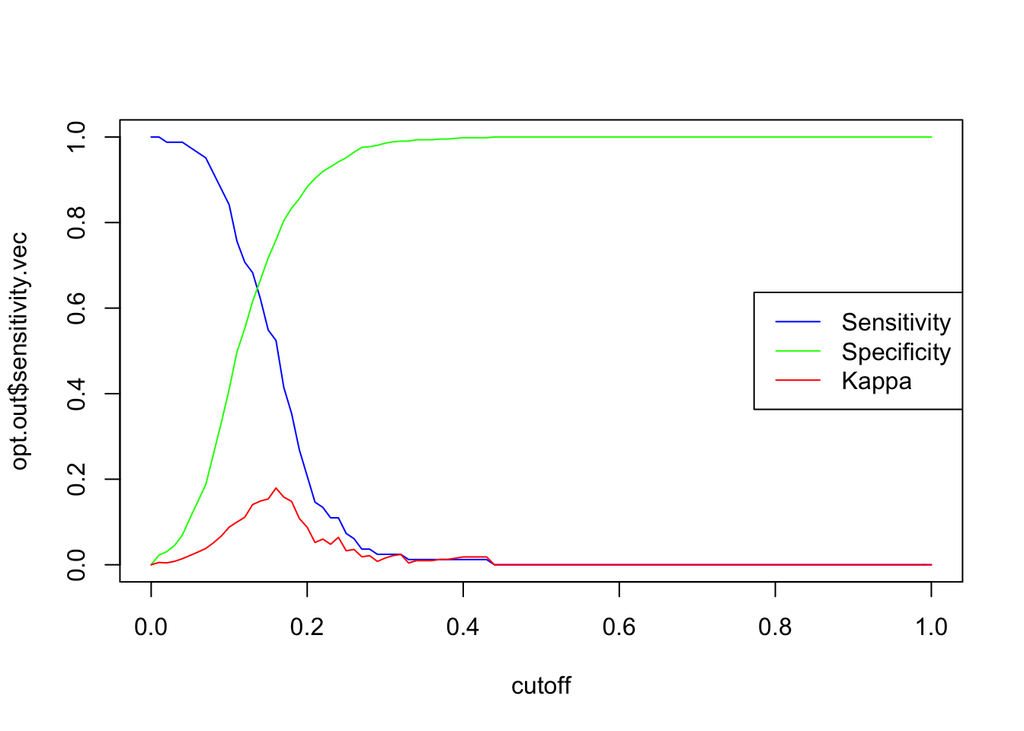

```r
opt.cut.plot(allreg.out0)
```

```r
allreg.out0$cutoff[which.min(allreg.out0$ssdiff.vec)]
```

```
## [1] 0.14
```

```r
allreg.out0.cut0 <- allreg.out0$cutoff[which.max(allreg.out0$kappa.vec)]
allreg.out0.cut0
```

```
## [1] 0.16
```

fit final model to combo of training and validation

```r
glmulti.out0 <- glmulti(popular ~ ., data = all.train0,
                           level = 1,               # No interaction considered
            method = "h",            # Exhaustive approach
            crit = "aic",            # AIC as criteria
            confsetsize = 5,         # Keep 5 best models
            plotty = F, report = F,  # No plot or interim reports
            fitfunction = "glm",     # lm function
            family = binomial)       # binomial to run logistic regression
#glmulti.out1@formulas
summary(glmulti.out0@objects[[1]])
```

```
##
## Call:
## fitfunc(formula = as.formula(x), family = ..1, data = data)
##
## Deviance Residuals:
##     Min       1Q   Median       3Q      Max
## -1.3693  -0.5839  -0.4678  -0.3410   2.5328
##
## Coefficients:
##                  Estimate Std. Error z value Pr(>|z|)
## (Intercept)       5.52925    0.69057   8.007 1.18e-15 ***
## duration         -0.59670    0.09474  -6.298 3.01e-10 ***
## acousticness     -1.37480    0.34513  -3.983 6.79e-05 ***
## energy           -3.73504    0.55851  -6.688 2.27e-11 ***
## instrumentalness -3.18012    2.09691  -1.517    0.129
## loudness          0.35966    0.04282   8.399  < 2e-16 ***
## speechiness       2.89618    0.68586   4.223 2.41e-05 ***
## valence          -1.45913    0.25130  -5.806 6.38e-09 ***
## ---
## Signif. codes:  0 '***' 0.001 '**' 0.01 '*' 0.05 '.' 0.1 ' ' 1
##
## (Dispersion parameter for binomial family taken to be 1)
##
##     Null deviance: 3128.4  on 3971  degrees of freedom
## Residual deviance: 2945.1  on 3964  degrees of freedom
## AIC: 2961.1
##
## Number of Fisher Scoring iterations: 6
```

store final model

```r
allreg.logit0.final <- glmulti.out0@objects[[1]]
```

Predictions with 0.5 as the cut off

```r
allreg.prob.test0 <- predict(allreg.logit0.final, newdata = logit.test0, type = "response")
allreg.pred.test0 <- ifelse(allreg.prob.test0 > 0.5, 1, 0) # using standard cutoff 0.5
confusionMatrix(as.factor(allreg.pred.test0), as.factor(logit.test0$popular), positive = "1")
```

```
## Confusion Matrix and Statistics
##
##           Reference
## Prediction   0   1
##          0 612  85
##          1   2   2
##
##                Accuracy : 0.8759
##                  95% CI : (0.8492, 0.8994)
##     No Information Rate : 0.8759
##     P-Value [Acc > NIR] : 0.5285
##
##                   Kappa : 0.0334
##
##  Mcnemar's Test P-Value : <2e-16
##
##             Sensitivity : 0.022989
##             Specificity : 0.996743
##          Pos Pred Value : 0.500000
##          Neg Pred Value : 0.878049
##              Prevalence : 0.124108
##          Detection Rate : 0.002853
##    Detection Prevalence : 0.005706
##       Balanced Accuracy : 0.509866
##
##        'Positive' Class : 1
##
```

Predictions where cut off is the best kappa

```r
allreg.prob.test0 <- predict(allreg.logit0.final, newdata = logit.test0, type = "response")
allreg.pred.test0 <- ifelse(allreg.prob.test0 > allreg.out0.cut0, 1, 0) # using standard cutoff 0.5
confusionMatrix(as.factor(allreg.pred.test0), as.factor(logit.test0$popular), positive = "1")
```

```
## Confusion Matrix and Statistics
##
##           Reference
## Prediction   0   1
##          0 467  51
##          1 147  36
##
##                Accuracy : 0.7175
##                  95% CI : (0.6826, 0.7506)
##     No Information Rate : 0.8759
##     P-Value [Acc > NIR] : 1
##
##                   Kappa : 0.1183
##
##  Mcnemar's Test P-Value : 1.465e-11
##
##             Sensitivity : 0.41379
##             Specificity : 0.76059
##          Pos Pred Value : 0.19672
##          Neg Pred Value : 0.90154
##              Prevalence : 0.12411
##          Detection Rate : 0.05136
##    Detection Prevalence : 0.26106
##       Balanced Accuracy : 0.58719
##
##        'Positive' Class : 1
##
```

Predictions where cut off is the best balance of sensitivity and specificity

```r
allreg.prob.test0 <- predict(allreg.logit0.final, newdata = logit.test0, type = "response")
allreg.pred.test0 <- ifelse(allreg.prob.test0 > 0.14, 1, 0) # using standard cutoff 0.5
confusionMatrix(as.factor(allreg.pred.test0), as.factor(logit.test0$popular), positive = "1")
```

```
## Confusion Matrix and Statistics
##
##           Reference
## Prediction   0   1
##          0 403  37
##          1 211  50
##
##                Accuracy : 0.6462
##                  95% CI : (0.6096, 0.6816)
##     No Information Rate : 0.8759
##     P-Value [Acc > NIR] : 1
##
##                   Kappa : 0.1243
##
##  Mcnemar's Test P-Value : <2e-16
##
##             Sensitivity : 0.57471
##             Specificity : 0.65635
##          Pos Pred Value : 0.19157
##          Neg Pred Value : 0.91591
##              Prevalence : 0.12411
##          Detection Rate : 0.07133
##    Detection Prevalence : 0.37233
##       Balanced Accuracy : 0.61553
##
##        'Positive' Class : 1
##
```

## Mode 1 popularity

### Full Logistic Model: train/valid/test

fitting logistic model using combo of train/valid/test, finding optimal model using training data.

```r
# Fit logistic model on training data
v.logit.model1 <- glm(popular ~ ., family=binomial(link='logit'),data= logit.train1)

#search for best cutoff
out1 <- opt.cut.func(v.logit.model1, logit.valid1)
```

[output not shown]

[output cut: 176 more lines]

[output not shown]

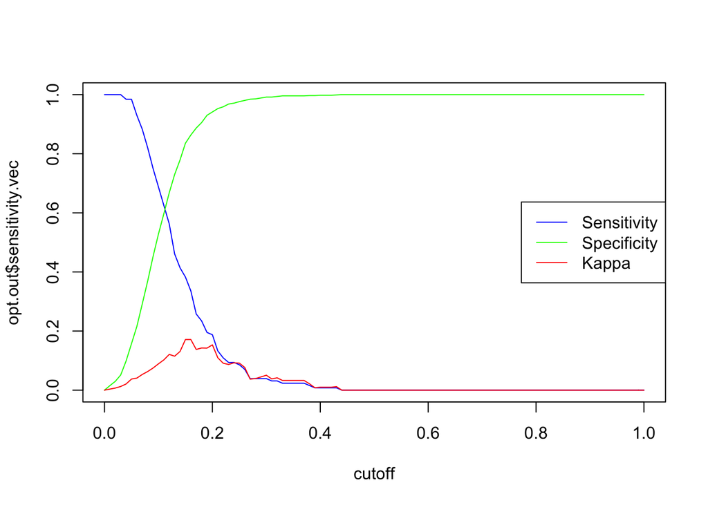

```r
opt.cut.plot(out1)
```

```r
out1$cutoff[which.min(out1$ssdiff.vec)]
```

```
## [1] 0.11
```

```r
v.opt.cut1 <- out1$cutoff[which.max(out1$kappa.vec)]
v.opt.cut1
```

```
## [1] 0.16
```

Fit final model (combo of train and validation)

```r
v.model.final1 <-  glm(popular ~ ., data=all.train1, family=binomial(link='logit'))
```

predict on test using 0.5 cutoff

```r
v.prob.test1 <- predict(v.logit.model1, newdata = logit.test1, type = "response")
v.pred.test1 <- ifelse(v.prob.test1 > 0.5, 1, 0) # using cutoff = 0.15
confusionMatrix(as.factor(v.pred.test1), as.factor(logit.test1$popular), positive = "1")
```

```
## Confusion Matrix and Statistics
##
##           Reference
## Prediction   0   1
##          0 981 120
##          1   0   0
##
##                Accuracy : 0.891
##                  95% CI : (0.8711, 0.9088)
##     No Information Rate : 0.891
##     P-Value [Acc > NIR] : 0.5243
##
##                   Kappa : 0
##
##  Mcnemar's Test P-Value : <2e-16
##
##             Sensitivity : 0.000
##             Specificity : 1.000
##          Pos Pred Value :   NaN
##          Neg Pred Value : 0.891
##              Prevalence : 0.109
##          Detection Rate : 0.000
##    Detection Prevalence : 0.000
##       Balanced Accuracy : 0.500
##
##        'Positive' Class : 1
##
```

predict on test using optimal cutoff (kappa)

```r
v.prob.test1 <- predict(v.logit.model1, newdata = logit.test1, type = "response")
v.pred.test1 <- ifelse(v.prob.test1 > v.opt.cut1, 1, 0) # using cutoff = 0.16
confusionMatrix(as.factor(v.pred.test1), as.factor(logit.test1$popular), positive = "1")
```

```
## Confusion Matrix and Statistics
##
##           Reference
## Prediction   0   1
##          0 852  78
##          1 129  42
##
##                Accuracy : 0.812
##                  95% CI : (0.7876, 0.8347)
##     No Information Rate : 0.891
##     P-Value [Acc > NIR] : 1.0000000
##
##                   Kappa : 0.1842
##
##  Mcnemar's Test P-Value : 0.0005104
##
##             Sensitivity : 0.35000
##             Specificity : 0.86850
##          Pos Pred Value : 0.24561
##          Neg Pred Value : 0.91613
##              Prevalence : 0.10899
##          Detection Rate : 0.03815
##    Detection Prevalence : 0.15531
##       Balanced Accuracy : 0.60925
##
##        'Positive' Class : 1
##
```

predict on test using optimal cutoff (sensitivity and specificity)

```r
v.prob.test1 <- predict(v.logit.model1, newdata = logit.test1, type = "response")
v.pred.test1 <- ifelse(v.prob.test1 > 0.11, 1, 0) # using cutoff = 0.11
confusionMatrix(as.factor(v.pred.test1), as.factor(logit.test1$popular), positive = "1")
```

```
## Confusion Matrix and Statistics
##
##           Reference
## Prediction   0   1
##          0 614  45
##          1 367  75
##
##                Accuracy : 0.6258
##                  95% CI : (0.5965, 0.6545)
##     No Information Rate : 0.891
##     P-Value [Acc > NIR] : 1
##
##                   Kappa : 0.1152
##
##  Mcnemar's Test P-Value : <2e-16
##
##             Sensitivity : 0.62500
##             Specificity : 0.62589
##          Pos Pred Value : 0.16968
##          Neg Pred Value : 0.93171
##              Prevalence : 0.10899
##          Detection Rate : 0.06812
##    Detection Prevalence : 0.40145
##       Balanced Accuracy : 0.62545
##
##        'Positive' Class : 1
##
```

### Variable Selection: Stepwise (10 fold CV)

step-wise 10 fold cross validation

```r
set.seed(123)
train_control <- trainControl(method = "cv",
                              number = 10)

# Fit K-fold CV model
meh <- capture.output(step1_kcv <- train(popular ~ ., data = logit.train1, family = binomial(),
                 method = "glmStepAIC", trControl = train_control, verbose = FALSE))
```

```r
step1_kcv <- step1_kcv$finalModel
step1_kcv
```

```
##
## Call:  NULL
##
## Coefficients:
##      (Intercept)          duration      acousticness      danceability
##         2.794494         -0.472134         -0.780411          0.825490
##           energy  instrumentalness              key1              key3
##        -2.993324         -9.356004          0.228479          0.445987
##             key6              key8             key10          loudness
##        -0.309803          0.403568         -0.761916          0.294721
##      speechiness             tempo           valence
##         4.242426          0.002515         -1.200140
##
## Degrees of Freedom: 5136 Total (i.e. Null);  5122 Residual
## Null Deviance:       3539
## Residual Deviance: 3337  AIC: 3367
```

```r
#search for best cutoff
kcv.out1 <- opt.cut.func(step1_kcv, key.dummy(logit.valid1))
```

[output not shown]

[output cut: 172 more lines]

[output not shown]

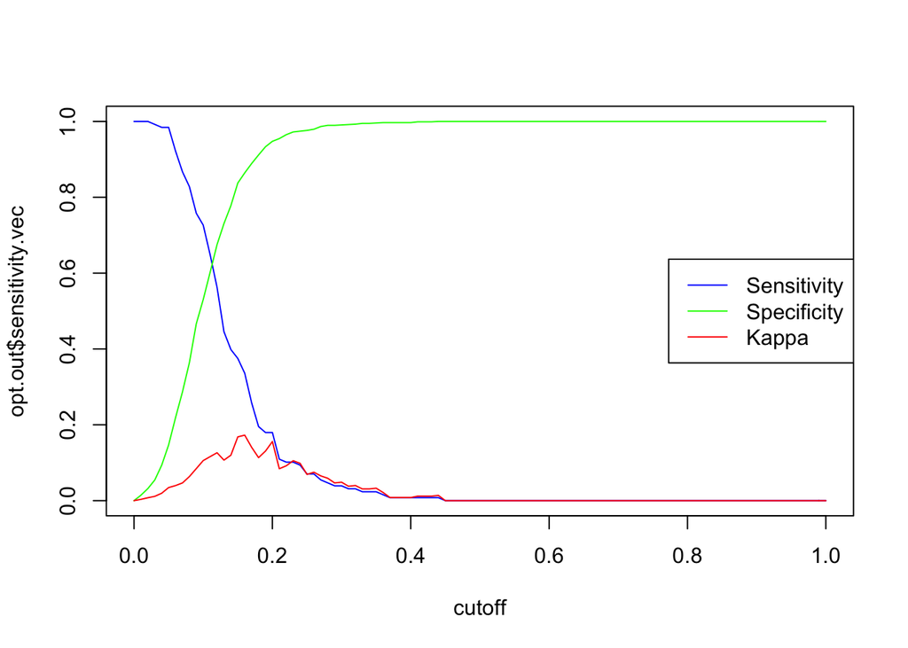

```r
opt.cut.plot(kcv.out1)
```

```r
kcv.out1$cutoff[which.min(kcv.out1$ssdiff.vec)]
```

```
## [1] 0.11
```

```r
kcv.out1.cut1 <- kcv.out1$cutoff[which.max(kcv.out1$kappa.vec)]
kcv.out1.cut1
```

```
## [1] 0.16
```

Fit final model (combo of train and validation)

```r
finalmeh <- capture.output(step1_kcv.final <- train(popular ~ ., data = all.train1, family = binomial(),
                 method = "glmStepAIC", trControl = train_control, verbose = FALSE))
```

```r
step1_kcv.final <- step1_kcv.final$finalModel
step1_kcv.final
```

```
##
## Call:  NULL
##
## Coefficients:
##      (Intercept)          duration      acousticness            energy
##           3.8603           -0.4608           -0.9135           -3.2870
## instrumentalness              key1              key3              key7
##         -10.1688            0.2417            0.4720            0.1873
##             key8             key10          loudness       speechiness
##           0.3123           -0.6641            0.3175            4.6203
##          valence
##          -1.1511
##
## Degrees of Freedom: 6237 Total (i.e. Null);  6225 Residual
## Null Deviance:       4331
## Residual Deviance: 4081  AIC: 4107
```

predict on test using 0.5 cutoff

```r
kcv.prob.test1 <- predict(step1_kcv.final, newdata = key.dummy(logit.test1), type = "response")
kcv.pred.test1 <- ifelse(kcv.prob.test1 > 0.5, 1, 0) # using cutoff = 0.5
confusionMatrix(as.factor(kcv.pred.test1), as.factor(logit.test1$popular), positive = "1")
```

```
## Confusion Matrix and Statistics
##
##           Reference
## Prediction   0   1
##          0 981 120
##          1   0   0
##
##                Accuracy : 0.891
##                  95% CI : (0.8711, 0.9088)
##     No Information Rate : 0.891
##     P-Value [Acc > NIR] : 0.5243
##
##                   Kappa : 0
##
##  Mcnemar's Test P-Value : <2e-16
##
##             Sensitivity : 0.000
##             Specificity : 1.000
##          Pos Pred Value :   NaN
##          Neg Pred Value : 0.891
##              Prevalence : 0.109
##          Detection Rate : 0.000
##    Detection Prevalence : 0.000
##       Balanced Accuracy : 0.500
##
##        'Positive' Class : 1
##
```

```r
kcv.prob.test1 <- predict(step1_kcv.final, newdata = key.dummy(logit.test1), type = "response")
kcv.pred.test1 <- ifelse(kcv.prob.test1 > kcv.out1.cut1, 1, 0) # using cutoff = 0.5
confusionMatrix(as.factor(kcv.pred.test1), as.factor(logit.test1$popular), positive = "1")
```

```
## Confusion Matrix and Statistics
##
##           Reference
## Prediction   0   1
##          0 860  77
##          1 121  43
##
##                Accuracy : 0.8202
##                  95% CI : (0.7962, 0.8424)
##     No Information Rate : 0.891
##     P-Value [Acc > NIR] : 1.000000
##
##                   Kappa : 0.2024
##
##  Mcnemar's Test P-Value : 0.002244
##
##             Sensitivity : 0.35833
##             Specificity : 0.87666
##          Pos Pred Value : 0.26220
##          Neg Pred Value : 0.91782
##              Prevalence : 0.10899
##          Detection Rate : 0.03906
##    Detection Prevalence : 0.14896
##       Balanced Accuracy : 0.61749
##
##        'Positive' Class : 1
##
```

```r
kcv.prob.test1 <- predict(step1_kcv.final, newdata = key.dummy(logit.test1), type = "response")
kcv.pred.test1 <- ifelse(kcv.prob.test1 > 0.11, 1, 0) # using cutoff = 0.5
confusionMatrix(as.factor(kcv.pred.test1), as.factor(logit.test1$popular), positive = "1")
```

```
## Confusion Matrix and Statistics
##
##           Reference
## Prediction   0   1
##          0 613  41
##          1 368  79
##
##                Accuracy : 0.6285
##                  95% CI : (0.5992, 0.6571)
##     No Information Rate : 0.891
##     P-Value [Acc > NIR] : 1
##
##                   Kappa : 0.129
##
##  Mcnemar's Test P-Value : <2e-16
##
##             Sensitivity : 0.65833
##             Specificity : 0.62487
##          Pos Pred Value : 0.17673
##          Neg Pred Value : 0.93731
##              Prevalence : 0.10899
##          Detection Rate : 0.07175
##    Detection Prevalence : 0.40599
##       Balanced Accuracy : 0.64160
##
##        'Positive' Class : 1
##
```

### Variable Selection: All possible regression

```r
glmulti.out1 <- glmulti(popular ~ ., data = logit.train1,
                           level = 1,               # No interaction considered
            method = "h",            # Exhaustive approach
            crit = "aic",            # AIC as criteria
            confsetsize = 5,         # Keep 5 best models
            plotty = F, report = F,  # No plot or interim reports
            fitfunction = "glm",     # lm function
            family = binomial)       # binomial to run logistic regression
#glmulti.out1@formulas
```

view summary of top model

```r
summary(glmulti.out1@objects[[1]])
```

```
##
## Call:
## fitfunc(formula = as.formula(x), family = ..1, data = data)
##
## Deviance Residuals:
##     Min       1Q   Median       3Q      Max
## -1.5900  -0.5211  -0.4244  -0.3204   2.7066
##
## Coefficients:
##                  Estimate Std. Error z value Pr(>|z|)
## (Intercept)       3.40877    0.64025   5.324 1.01e-07 ***
## key1              0.40640    0.17128   2.373 0.017656 *
## key2              0.19206    0.18913   1.015 0.309871
## key3              0.61657    0.26373   2.338 0.019391 *
## key4              0.06052    0.25219   0.240 0.810341
## key5              0.27294    0.21266   1.283 0.199325
## key6             -0.13261    0.23385  -0.567 0.570673
## key7              0.29487    0.17257   1.709 0.087511 .
## key8              0.57705    0.18525   3.115 0.001839 **
## key9              0.25148    0.21075   1.193 0.232767
## key10            -0.59921    0.34957  -1.714 0.086508 .
## key11             0.17405    0.22797   0.763 0.445195
## duration         -0.48429    0.08956  -5.408 6.38e-08 ***
## acousticness     -0.87164    0.27646  -3.153 0.001617 **
## energy           -3.03009    0.52700  -5.750 8.94e-09 ***
## instrumentalness -9.26271    5.66036  -1.636 0.101752
## loudness          0.29248    0.03852   7.593 3.12e-14 ***
## speechiness       4.27734    0.60520   7.068 1.58e-12 ***
## valence          -0.96058    0.25248  -3.805 0.000142 ***
## ---
## Signif. codes:  0 '***' 0.001 '**' 0.01 '*' 0.05 '.' 0.1 ' ' 1
##
## (Dispersion parameter for binomial family taken to be 1)
##
##     Null deviance: 3538.8  on 5136  degrees of freedom
## Residual deviance: 3336.9  on 5118  degrees of freedom
## AIC: 3374.9
##
## Number of Fisher Scoring iterations: 8
```

Store model

```r
allreg.logit1 <- glmulti.out1@objects[[1]]
```

```r
#search for best cutoff
allreg.out1 <- opt.cut.func(allreg.logit1, logit.valid1)
```

[output not shown]

[output cut: 180 more lines]

[output not shown]

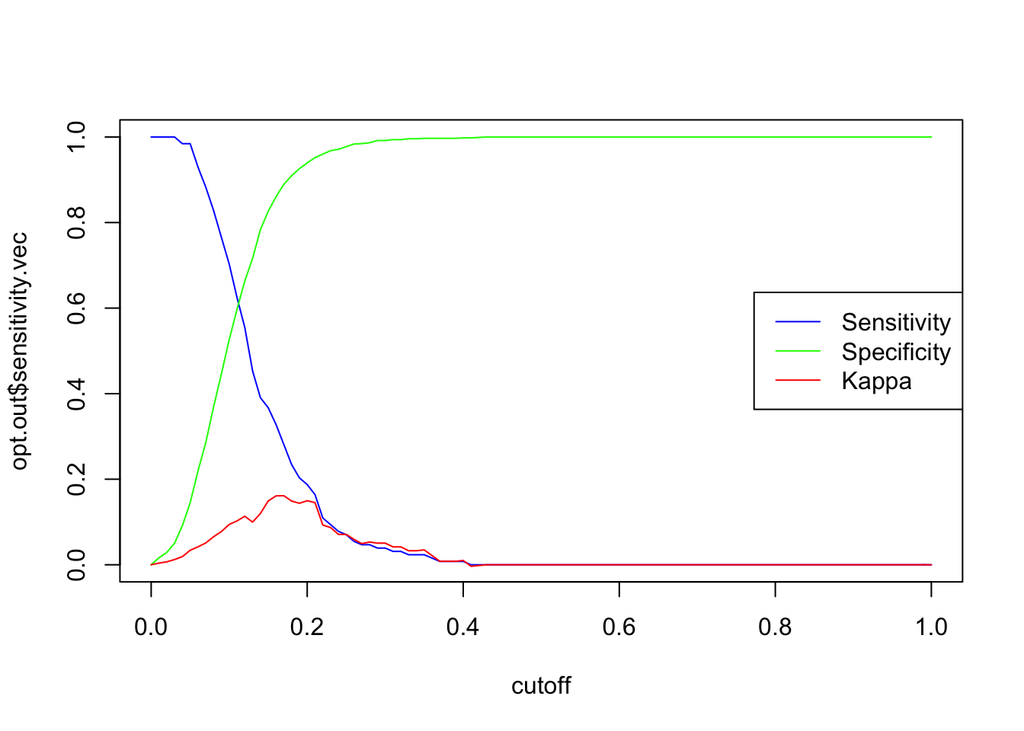

```r
opt.cut.plot(allreg.out1)
```

```r
allreg.out1$cutoff[which.min(allreg.out1$ssdiff.vec)]
```

```
## [1] 0.11
```

```r
allreg.out1.cut1 <- allreg.out1$cutoff[which.max(allreg.out1$kappa.vec)]
allreg.out1.cut1
```

```
## [1] 0.17
```

fit final model to combo of training and validation

```r
glmulti.out1 <- glmulti(popular ~ ., data = all.train1,
                           level = 1,               # No interaction considered
            method = "h",            # Exhaustive approach
            crit = "aic",            # AIC as criteria
            confsetsize = 5,         # Keep 5 best models
            plotty = F, report = F,  # No plot or interim reports
            fitfunction = "glm",     # lm function
            family = binomial)       # binomial to run logistic regression
#glmulti.out1@formulas
summary(glmulti.out1@objects[[1]])
```

```
##
## Call:
## fitfunc(formula = as.formula(x), family = ..1, data = data)
##
## Deviance Residuals:
##     Min       1Q   Median       3Q      Max
## -1.6915  -0.5253  -0.4264  -0.3229   2.7069
##
## Coefficients:
##                   Estimate Std. Error z value Pr(>|z|)
## (Intercept)        3.72712    0.57666   6.463 1.02e-10 ***
## key1               0.33677    0.15638   2.153 0.031282 *
## key2               0.09558    0.17139   0.558 0.577083
## key3               0.56959    0.23659   2.407 0.016064 *
## key4              -0.07057    0.23466  -0.301 0.763620
## key5               0.17711    0.19456   0.910 0.362646
## key6               0.10956    0.19472   0.563 0.573691
## key7               0.28310    0.15530   1.823 0.068311 .
## key8               0.40766    0.17212   2.368 0.017866 *
## key9               0.27709    0.18592   1.490 0.136119
## key10             -0.56767    0.30894  -1.837 0.066140 .
## key11              0.11858    0.20819   0.570 0.568975
## duration          -0.46077    0.08095  -5.692 1.25e-08 ***
## acousticness      -0.91057    0.24755  -3.678 0.000235 ***
## energy            -3.26156    0.47404  -6.880 5.97e-12 ***
## instrumentalness -10.17761    5.79507  -1.756 0.079045 .
## loudness           0.31524    0.03482   9.055  < 2e-16 ***
## speechiness        4.60621    0.55922   8.237  < 2e-16 ***
## valence           -1.13490    0.22721  -4.995 5.89e-07 ***
## ---
## Signif. codes:  0 '***' 0.001 '**' 0.01 '*' 0.05 '.' 0.1 ' ' 1
##
## (Dispersion parameter for binomial family taken to be 1)
##
##     Null deviance: 4330.7  on 6237  degrees of freedom
## Residual deviance: 4077.6  on 6219  degrees of freedom
## AIC: 4115.6
##
## Number of Fisher Scoring iterations: 8
```

store final model

```r
allreg.logit1.final <- glmulti.out1@objects[[1]]
```

Predictions with 0.5 as the cut off

```r
allreg.prob.test1 <- predict(allreg.logit1.final, newdata = logit.test1, type = "response")
allreg.pred.test1 <- ifelse(allreg.prob.test1 > 0.5, 1, 0) # using standard cutoff 0.5
confusionMatrix(as.factor(allreg.pred.test1), as.factor(logit.test1$popular), positive = "1")
```

```
## Confusion Matrix and Statistics
##
##           Reference
## Prediction   0   1
##          0 981 120
##          1   0   0
##
##                Accuracy : 0.891
##                  95% CI : (0.8711, 0.9088)
##     No Information Rate : 0.891
##     P-Value [Acc > NIR] : 0.5243
##
##                   Kappa : 0
##
##  Mcnemar's Test P-Value : <2e-16
##
##             Sensitivity : 0.000
##             Specificity : 1.000
##          Pos Pred Value :   NaN
##          Neg Pred Value : 0.891
##              Prevalence : 0.109
##          Detection Rate : 0.000
##    Detection Prevalence : 0.000
##       Balanced Accuracy : 0.500
##
##        'Positive' Class : 1
##
```

Predictions where cut off is the best kappa

```r
allreg.prob.test1 <- predict(allreg.logit1.final, newdata = logit.test1, type = "response")
allreg.pred.test1 <- ifelse(allreg.prob.test1 > allreg.out1.cut1, 1, 0) # using optimal cutoff 0.17
confusionMatrix(as.factor(allreg.pred.test1), as.factor(logit.test1$popular), positive = "1")
```

```
## Confusion Matrix and Statistics
##
##           Reference
## Prediction   0   1
##          0 878  83
##          1 103  37
##
##                Accuracy : 0.8311
##                  95% CI : (0.8076, 0.8527)
##     No Information Rate : 0.891
##     P-Value [Acc > NIR] : 1.0000
##
##                   Kappa : 0.1895
##
##  Mcnemar's Test P-Value : 0.1636
##
##             Sensitivity : 0.30833
##             Specificity : 0.89501
##          Pos Pred Value : 0.26429
##          Neg Pred Value : 0.91363
##              Prevalence : 0.10899
##          Detection Rate : 0.03361
##    Detection Prevalence : 0.12716
##       Balanced Accuracy : 0.60167
##
##        'Positive' Class : 1
##
```

Predictions where cut off is the best balance of sensitivity and specificity

```r
allreg.prob.test1 <- predict(allreg.logit1.final, newdata = logit.test1, type = "response")
allreg.pred.test1 <- ifelse(allreg.prob.test1 > 0.11, 1, 0) # using optimal cutoff
confusionMatrix(as.factor(allreg.pred.test1), as.factor(logit.test1$popular), positive = "1")
```

```
## Confusion Matrix and Statistics
##
##           Reference
## Prediction   0   1
##          0 615  42
##          1 366  78
##
##                Accuracy : 0.6294
##                  95% CI : (0.6001, 0.658)
##     No Information Rate : 0.891
##     P-Value [Acc > NIR] : 1
##
##                   Kappa : 0.1267
##
##  Mcnemar's Test P-Value : <2e-16
##
##             Sensitivity : 0.65000
##             Specificity : 0.62691
##          Pos Pred Value : 0.17568
##          Neg Pred Value : 0.93607
##              Prevalence : 0.10899
##          Detection Rate : 0.07084
##    Detection Prevalence : 0.40327
##       Balanced Accuracy : 0.63846
##
##        'Positive' Class : 1
##
```